# BMI 567/667 Networkx Tutorial

# (end) Excercise 5

# Let's think about how to visualize our graph in a new way.

Instead of plotting all the nodes, let's take a `graph coarsening` approach: Nodes will now represent communities (# members ~ node size) and edges represent the number of member interactions with proteins in other communities.

```python
communities = [x for x in coms if len(x) > 50] # filter our network to only communities with X members

newG = nx.Graph()
for i,com1 in enumerate(communities):
    print('Size of node {}: {}'.format(i, len(com1)))
    newG.add_node(i, size= len(com1))

weights = []

# add edges
for i,com1 in enumerate(communities):
    print(f'progress: {i/len(communities)*100:.1f} %', end='\r')
    for j,com2 in enumerate(communities[i:]):
        shared_edges = list(nx.algorithms.boundary.edge_boundary(fi_G2, com1, com2))
        weight = len(shared_edges) / min([len(nx.subgraph(fi_G2, com1).edges()), len(nx.subgraph(fi_G2, com2).edges())])
        weights.append(weight)
        if weight > 0.1:
            newG.add_edge(i,j, n_edges=len(shared_edges), weight=weight)

newG.remove_edges_from(nx.selfloop_edges(newG))
```

```
Size of node 0: 614
Size of node 1: 149
Size of node 2: 62
Size of node 3: 927
Size of node 4: 361
Size of node 5: 1609
Size of node 6: 648
Size of node 7: 1174
Size of node 8: 55
Size of node 9: 1140
Size of node 10: 110
Size of node 11: 1322
Size of node 12: 61
Size of node 13: 687
Size of node 14: 643
Size of node 15: 2407
Size of node 16: 161
Size of node 17: 135
Size of node 18: 919
progress: 94.7 %
```

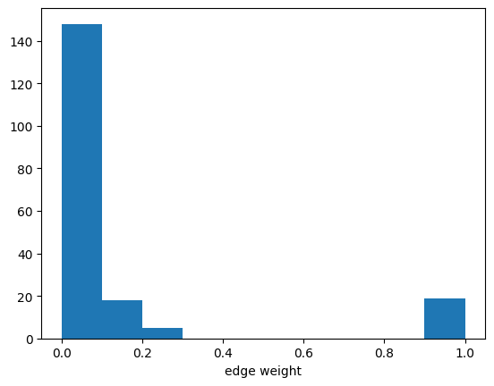

```python
plt.figure()
plt.hist(weights)
plt.xlabel('edge weight')
plt.show()
```

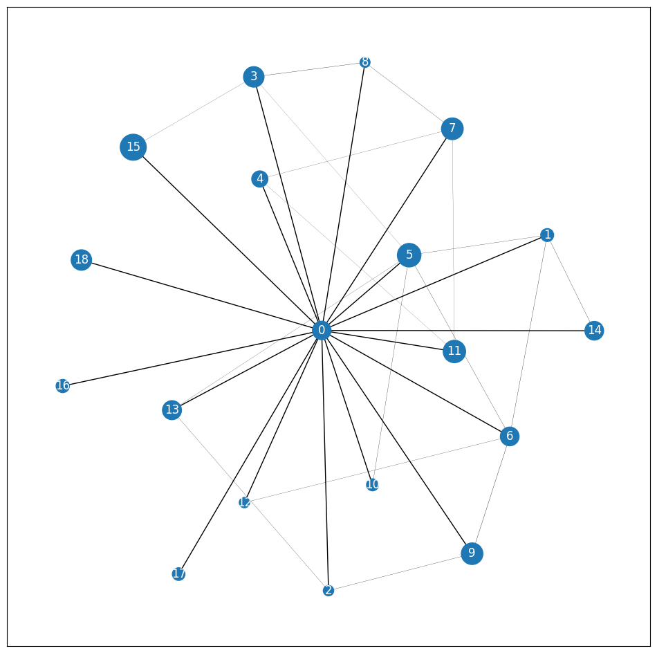

```python
pos = nx.spring_layout(newG)

plt.figure(figsize=(12,12))
nx.draw_networkx_nodes(newG, pos=pos, nodelist=newG.nodes(), node_size=15*np.array(list(nx.get_node_attributes(newG, 'size').values()))**(0.5))
nx.draw_networkx_labels(newG, pos=pos, font_color='w')
nx.draw_networkx_edges(newG, pos=pos, edgelist=newG.edges(), width=np.array(list(nx.get_edge_attributes(newG, 'weight').values())))
plt.figure()
```

# Other Resources

The `Stanford Network Analysis Project` has some excellent resources including a wide range of graph datasets. These may be useful for your term project and I highly recommend exploring their website:

- [SNAP](http://snap.stanford.edu/index.html)
- [SNAP bio datasets](http://snap.stanford.edu/biodata/index.html)
- [SNAP for python](http://snap.stanford.edu/snappy/index.html)